# Assignment 9: Graduate School Admissions

Ousmane Doumbia

## Research question

How are GRE score, GPA, and undergraduate institution rank associated with graduate school admission? Admission is coded as 1 for admitted and 0 for not admitted, so I will use logistic regression.

## Load and clean the data

```r
raw <- read.csv("../../Data/GradSchool_Admissions.csv")
admissions <- raw[complete.cases(raw), ]
admissions$rank <- factor(admissions$rank)

nrow(raw)
```

```
## [1] 400
```

```r
nrow(admissions)
```

```
## [1] 400
```

```r
summary(admissions)
```

```
##      admit             gre             gpa        rank
##  Min.   :0.0000   Min.   :220.0   Min.   :2.260   1: 61
##  1st Qu.:0.0000   1st Qu.:520.0   1st Qu.:3.130   2:151
##  Median :0.0000   Median :580.0   Median :3.395   3:121
##  Mean   :0.3175   Mean   :587.7   Mean   :3.390   4: 67
##  3rd Qu.:1.0000   3rd Qu.:660.0   3rd Qu.:3.670
##  Max.   :1.0000   Max.   :800.0   Max.   :4.000
```

## Explore the data

```r
admission_rate <- with(admissions, tapply(admit, rank, mean))
round(100 * admission_rate, 1)
```

```
##    1    2    3    4
## 54.1 35.8 23.1 17.9
```

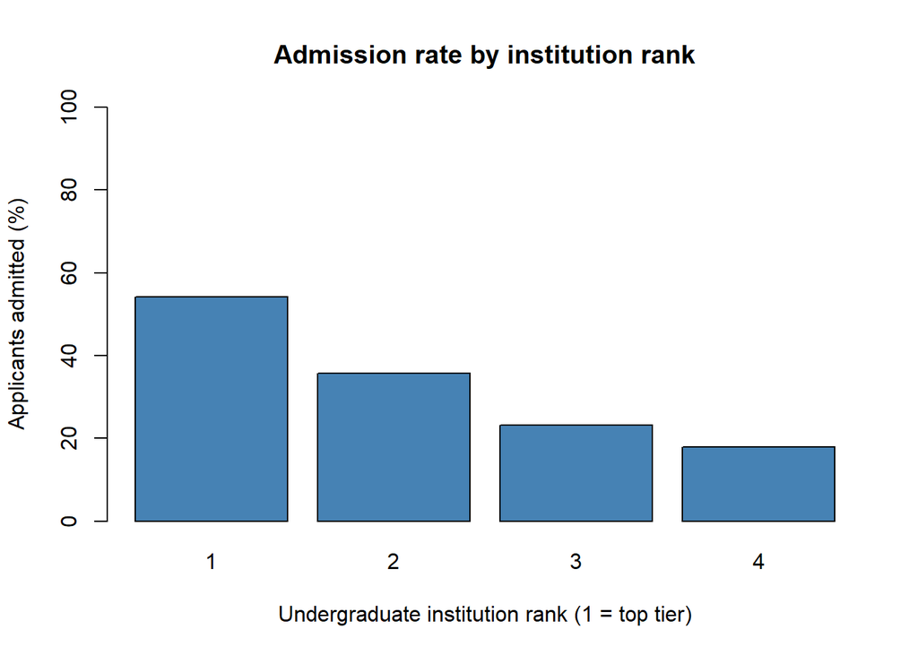

```r
barplot(
  100 * admission_rate,
  main = "Admission rate by institution rank",
  xlab = "Undergraduate institution rank (1 = top tier)",
  ylab = "Applicants admitted (%)",
  ylim = c(0, 100),
  col = "steelblue"
)
```

The observed admission rate was highest for rank 1 (54.1%) and lowest for rank 4 (17.9%). These rates are calculated before accounting for GRE scores and GPA.

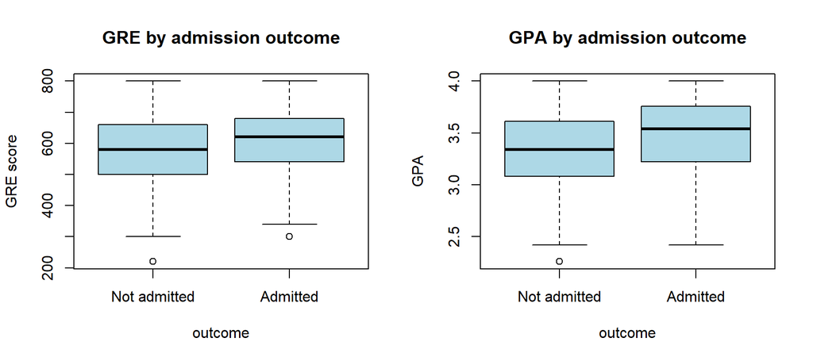

```r
outcome <- factor(admissions$admit, levels = c(0, 1),
                  labels = c("Not admitted", "Admitted"))

par(mfrow = c(1, 2))
boxplot(gre ~ outcome, data = admissions,
        main = "GRE by admission outcome", ylab = "GRE score",
        col = "lightblue")
boxplot(gpa ~ outcome, data = admissions,
        main = "GPA by admission outcome", ylab = "GPA",
        col = "lightblue")
```

```r
par(mfrow = c(1, 1))
```

Admitted applicants had higher median GRE scores and GPAs, although the distributions overlapped in both plots.

## Logistic regression

I compare a model with GRE and GPA to a model that also includes institution rank. This tests whether rank adds information about admission after accounting for GRE and GPA.

```r
model_scores <- glm(admit ~ gre + gpa,
                    data = admissions, family = binomial())

model_full <- glm(admit ~ gre + gpa + rank,
                  data = admissions, family = binomial())

AIC(model_scores, model_full)
```

```
##              df      AIC
## model_scores  3 486.3440
## model_full    6 470.5175
```

```r
anova(model_scores, model_full, test = "Chisq")
```

```
## Analysis of Deviance Table
##
## Model 1: admit ~ gre + gpa
## Model 2: admit ~ gre + gpa + rank
##   Resid. Df Resid. Dev Df Deviance  Pr(>Chi)
## 1       397     480.34
## 2       394     458.52  3   21.826 7.088e-05 ***
## ---
## Signif. codes:  0 '***' 0.001 '**' 0.01 '*' 0.05 '.' 0.1 ' ' 1
```

```r
summary(model_full)
```

```
##
## Call:
## glm(formula = admit ~ gre + gpa + rank, family = binomial(),
##     data = admissions)
##
## Coefficients:
##              Estimate Std. Error z value Pr(>|z|)
## (Intercept) -3.989979   1.139951  -3.500 0.000465 ***
## gre          0.002264   0.001094   2.070 0.038465 *
## gpa          0.804038   0.331819   2.423 0.015388 *
## rank2       -0.675443   0.316490  -2.134 0.032829 *
## rank3       -1.340204   0.345306  -3.881 0.000104 ***
## rank4       -1.551464   0.417832  -3.713 0.000205 ***
## ---
## Signif. codes:  0 '***' 0.001 '**' 0.01 '*' 0.05 '.' 0.1 ' ' 1
##
## (Dispersion parameter for binomial family taken to be 1)
##
##     Null deviance: 499.98  on 399  degrees of freedom
## Residual deviance: 458.52  on 394  degrees of freedom
## AIC: 470.52
##
## Number of Fisher Scoring iterations: 4
```

## Conclusion

I selected the model with GRE score, GPA, and institution rank because it had a lower AIC than the model with GRE and GPA alone (470.52 vs. 486.34). The likelihood-ratio test also showed that adding institution rank improved model fit (p = 0.000071).

In the full model, higher GRE scores and GPAs were associated with higher odds of admission. At the same GRE score and GPA, applicants from rank 4 institutions had about 79% lower estimated odds of admission than applicants from rank 1 institutions. These results describe associations in this sample.